# p8105_hw1_jz3899

Jicong Zhang

2025-09-20

# Problem 1

Load the dataset

```r
library(moderndive)
data("early_january_weather")
```

Show the size of the dataset and the mean of the temperature

```r
nrow(early_january_weather)
```

```
## [1] 358
```

```r
ncol(early_january_weather)
```

```
## [1] 15
```

```r
mean(early_january_weather$temp)
```

```
## [1] 39.58212
```

**This dataset shows the weather condition of EWR in January 2013. It collected data like the temperature, the humidity, the wind speed, the pressure and visibility every hour and every day in January 2013. There are 358 rows and 15 columns in this dataset. The mean of the temperature is 39.58 F.**

Make a scatter plot of hour and temperature. Use humidity as a third dimension.

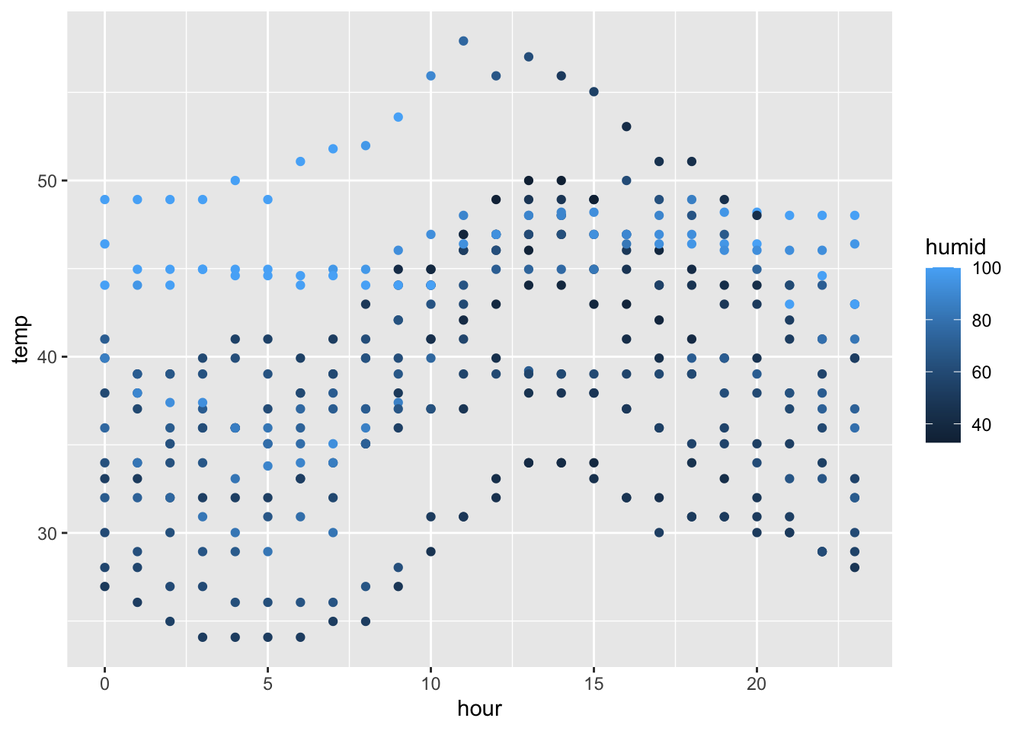

```r
ggplot(early_january_weather, aes(x = hour, y = temp, color = humid)) +
  geom_point()
```

```r
ggsave("hour_vs_temp.pdf", height = 4, width = 6)
```

**The temperature of the day will rise during daytime, often begins at 5 am. After 12 pm, the temperature begins to dip until the next day’s early morning. And higher humidity seems to correspond to higher temperature.**

# Problem 2

Create the dataframe

```r
hw1_df = tibble(
  vec_num = rnorm(10),
  vec_log = (vec_num > 0),
  vec_char = c("A", "B", "C", "D", "E", "F", "G", "H", "I", "J"),
  vec_factor = factor(c("Level 1", "Level 2", "Level 3", "Level 1", "Level 2", "Level 3", "Level 1", "Level 2", "Level 3", "Level 1"))
)
hw1_df
```

```
## # A tibble: 10 × 4
##    vec_num vec_log vec_char vec_factor
##      <dbl> <lgl>   <chr>    <fct>
##  1 -0.278  FALSE   A        Level 1
##  2  1.80   TRUE    B        Level 2
##  3  0.0123 TRUE    C        Level 3
##  4 -1.92   FALSE   D        Level 1
##  5 -0.293  FALSE   E        Level 2
##  6 -0.397  FALSE   F        Level 3
##  7  1.66   TRUE    G        Level 1
##  8 -1.68   FALSE   H        Level 2
##  9 -0.648  FALSE   I        Level 3
## 10  0.648  TRUE    J        Level 1
```

Take the mean of each variable

```r
mean(pull(hw1_df, var = vec_num))
```

```
## [1] -0.1092914
```

```r
mean(pull(hw1_df, var = vec_log))
```

```
## [1] 0.4
```

```r
mean(pull(hw1_df, var = vec_char))
```

```
## [1] NA
```

```r
mean(pull(hw1_df, var = vec_factor))
```

```
## [1] NA
```

**Sample of size 10 and the logical vector works well. Character vector and factor vector does not work.**

Convert all the variables to numeric

```r
as.numeric(pull(hw1_df, var = vec_log))
```

```
##  [1] 0 1 1 0 0 0 1 0 0 1
```

```r
as.numeric(pull(hw1_df, var = vec_char))
```

```
##  [1] NA NA NA NA NA NA NA NA NA NA
```

```r
as.numeric(pull(hw1_df, var = vec_factor))
```

```
##  [1] 1 2 3 1 2 3 1 2 3 1
```

**Logical vector and factor vector can be converted to numeric. Character vector can not be converted to numeric. It is because characters can not be directly turned into numbers. This explains why we can get the mean of logical vector. Because R convert true and false to 1 and 0.**